# Quasistatic methods in dem

true  
May 12, 2023

Shah Nawaz: whaaat is rigid body in discrete element modelling

Raycast AI: In discrete element modelling, a rigid body refers to an object that maintains its shape and size throughout a simulation, and its motion is governed by the laws of physics such as Newtons laws of motion. Rigid bodies are often used to model solid objects in simulations involving granular materials, powders, or other types of discrete particles. These simulations can be used to study the behavior of materials under different conditions, such as during manufacturing processes or in natural phenomena like landslides or avalanches.

Shah Nawaz: what is inertia

Raycast AI: Inertia is a property of matter that describes its resistance to a change in motion. Specifically, it is the tendency of an object to remain at rest or in uniform motion in a straight line unless acted upon by an external force. The greater an object’s mass, the greater its inertia, and the harder it is to change its motion. Inertia is a fundamental concept in physics and is closely related to Newton’s first law of motion, which states that an object at rest will remain at rest, and an object in motion will remain in motion at a constant velocity, unless acted upon by an external force.

Shah Nawaz: how equations of motion are integrated

Raycast AI: The equations of motion are typically integrated using numerical methods, which involve dividing the motion into small time steps and approximating the position and velocity of an object at each time step. One common numerical method for integrating the equations of motion is the Euler method, which involves using the current position and velocity of an object to estimate its position and velocity at the next time step. Another common method is the Runge-Kutta method, which is a more accurate and stable method that uses multiple estimates of the position and velocity at each time step to improve the accuracy of the integration. Other numerical methods, such as the Verlet method or the Leapfrog method, are also commonly used to integrate the equations of motion in different types of simulations.

Shah Nawaz: show this process with equations

Raycast AI: Sure, let me explain the Euler method as an example.

The Euler method is a simple numerical method for integrating the equations of motion. It involves using the current position and velocity of an object to estimate its position and velocity at the next time step. The basic idea is to use the derivative of the position and velocity with respect to time to estimate the change in position and velocity over a small time step. Mathematically, the Euler method can be expressed as follows:

Given an object with position `x`, velocity `v`, and acceleration `a`, the position and velocity at time `t+Δt` can be estimated as:

```
x(t + Δt) ≈ x(t) + v(t)Δt
v(t + Δt) ≈ v(t) + a(t)Δt
```

where `Δt` is the time step, which is a small, fixed interval of time.

These equations can be used to update the position and velocity of the object at each time step of the simulation. However, it is important to note that the Euler method is a first-order method, which means that it can introduce errors that accumulate over time. Therefore, more advanced numerical methods, such as the Runge-Kutta method or the Verlet method, are often used for more accurate simulations.

Shah Nawaz: how we can code that in r

Raycast AI: Sure, I can provide an example of how to implement the Euler method in R.

Here’s an example code that shows how to use the Euler method to simulate the motion of a particle under the influence of a constant force:

```r
# Define initial conditions
x0 <- 0    # initial position
v0 <- 10   # initial velocity
a <- -9.8  # acceleration due to gravity
dt <- 0.1  # time step

# Initialize arrays to store position and velocity
x <- numeric(100)
v <- numeric(100)

# Set initial values
x[1] <- x0
v[1] <- v0

# Use Euler method to update position and velocity
for (i in 2:100) {
  x[i] <- x[i-1] + v[i-1] * dt
  v[i] <- v[i-1] + a * dt
}

# Plot the results
plot(x, type="l", xlab="Time", ylab="Position", main="Motion under constant acceleration")
```

In this example, we define the initial conditions (position, velocity, acceleration, and time step), initialize arrays to store the position and velocity at each time step, and then use a for loop to update the position and velocity using the Euler method. Finally, we plot the results to visualize the motion of the particle over time.

Shah Nawaz: what is i-1 is doing

Raycast AI: In the context of the code example I provided earlier, the `i-1` index is used to refer to the previous time step in the Euler method update equations.

Specifically, in the for loop that updates the position and velocity using the Euler method, the position and velocity at time `i` are updated using the position and velocity at time `i-1`. This is because the Euler method uses the current position and velocity to estimate the position and velocity at the next time step.

So, in the line of code `x[i] <- x[i-1] + v[i-1] * dt`, `x[i-1]` refers to the position at the previous time step, and `v[i-1]` refers to the velocity at the previous time step. Similarly, in the line of code `v[i] <- v[i-1] + a * dt`, `v[i-1]` refers to the velocity at the previous time step.

By using the previous time step values in the Euler method update equations, we can estimate the position and velocity of the particle at the next time step based on its current position, velocity, and acceleration.

Shah Nawaz: what is solid state continuum mechanics

Raycast AI: Solid state continuum mechanics is a branch of mechanics that deals with the behavior of solid materials under external loads. It is concerned with the study of the mechanical, thermal, and electromagnetic properties of solids, and how these properties affect the deformation, stress, and strain of a material.

In solid state continuum mechanics, materials are treated as continuous media, meaning that they are assumed to be homogeneous and continuous throughout their volume. This allows for the use of mathematical models to describe the behavior of materials under different types of loading conditions, such as tension, compression, bending, or torsion.

The mathematical models used in solid state continuum mechanics are typically based on the principles of conservation of mass, momentum, and energy, and are often expressed in terms of partial differential equations. These models can be used to predict the behavior of materials under different conditions, and are widely used in engineering and materials science to design and optimize structures and materials for specific applications.

Shah Nawaz: what is quasistatic in discrete element

Raycast AI: In discrete element modeling, quasistatic refers to a type of simulation in which the motion of particles is slow enough that inertial effects can be neglected. This means that the particles are assumed to be in static equilibrium at each time step, and their motion is governed solely by the forces acting on them.

In a quasistatic simulation, the time step is typically chosen to be much smaller than the characteristic time scale of the system, such as the time it takes for a particle to move its own diameter. This ensures that the motion of the particles is slow enough that inertial effects can be ignored, and the simulation can be treated as a series of static equilibrium states.

Quasistatic simulations are commonly used in discrete element modeling to study the behavior of granular materials, powders, and other types of discrete particles. They can be used to investigate the packing and flow properties of these materials, as well as their response to external loads and boundary conditions. Quasistatic simulations are also useful for studying the evolution of microstructures in materials, such as the formation of cracks or voids under applied stresses.

Shah Nawaz: what is static equilibrium

Raycast AI: Static equilibrium refers to a state in which an object is at rest or moving with a constant velocity, and the net force acting on it is zero. In other words, the object is in a state of balance, where the forces acting on it are equal and opposite, and there is no acceleration or change in motion.

In static equilibrium, the object may still be subject to external forces, but these forces are balanced by internal forces within the object. For example, a book resting on a table is in static equilibrium, as the weight of the book is balanced by the normal force exerted by the table. Similarly, a bridge or a building can be in static equilibrium if the forces acting on it are balanced, even though it may be subject to external loads such as wind or earthquakes.

Static equilibrium is an important concept in mechanics, as it is the basis for many engineering and design applications. By understanding the forces acting on an object in static equilibrium, engineers can design structures and machines that are stable and safe under different loading conditions.

Shah Nawaz: what is role of elastoplastic law in quasistatic

Raycast AI: In quasistatic simulations of granular materials and other types of discrete particles, the elastoplastic law is often used to model the mechanical behavior of the particles. The elastoplastic law is a constitutive law that describes the stress-strain behavior of a material undergoing deformation, and it is commonly used to model the behavior of materials that exhibit both elastic and plastic deformation.

In the context of quasistatic simulations, the elastoplastic law is used to model the deformation and failure of particles under external loads. The law relates the stress and strain of the particle, and it typically includes a yield criterion that defines the onset of plastic deformation. Once the yield criterion is exceeded, the material undergoes plastic deformation, which can lead to permanent deformation, particle rearrangement, and ultimately, failure.

The elastoplastic law is important in quasistatic simulations because it allows for the modeling of the complex mechanical behavior of granular materials and other types of discrete particles. By incorporating the elastoplastic law into the simulation, it is possible to predict the deformation and failure of the particles under different loading conditions, and to study the effects of particle properties, such as size, shape, and friction, on the overall behavior of the material.

Shah Nawaz: show this with equations

Raycast AI: Sure, I can provide an example of the elastoplastic law and how it is used in quasistatic simulations.

The elastoplastic law relates the stress and strain of a material undergoing deformation, and it is commonly expressed as a stress-strain curve. In its simplest form, the elastoplastic law can be expressed as follows:

```
σ = Eε       for ε < εy
σ = σy      for ε ≥ εy
```

where `σ` is the stress, `ε` is the strain, `E` is the elastic modulus, `εy` is the yield strain, and `σy` is the yield stress.

In this equation, the material is assumed to behave elastically for strains below the yield strain, `εy`. When the strain exceeds the yield strain, the material undergoes plastic deformation, and the stress remains constant at the yield stress, `σy`. This is known as the yield criterion, and it is used to define the onset of plastic deformation in the material.

In quasistatic simulations, the elastoplastic law is used to model the deformation and failure of particles under external loads. The law is typically incorporated into the simulation as a constitutive model that relates the stress and strain of each particle. The particles are assumed to behave elastically until the yield criterion is exceeded, at which point they undergo plastic deformation.

The elastoplastic law can be used to predict the deformation and failure of particles under different loading conditions, and to study the effects of particle properties, such as size, shape, and friction, on the overall behavior of the material.

Shah Nawaz: how linear elastic model of discrete element can be linked to this

Raycast AI: The linear elastic model is a special case of the elastoplastic model, where the material behaves elastically for all strains, and there is no plastic deformation. In the context of discrete element modeling, the linear elastic model is often used to represent the behavior of particles that are relatively stiff and do not undergo significant plastic deformation.

In the linear elastic model, the stress-strain relationship is described by Hooke’s law, which states that the stress is proportional to the strain. Mathematically, this can be expressed as:

```
σ = Eε
```

where `σ` is the stress, `ε` is the strain, and `E` is the elastic modulus of the material. This equation describes the linear relationship between stress and strain in an elastic material, and it is used to calculate the deformation of a particle under an applied load.

In discrete element modeling, the linear elastic model can be used to represent the behavior of particles that are subject to small deformations under external loads. The linear elastic model can be linked to the elastoplastic model by considering the yield criterion, which defines the onset of plastic deformation in the material. If the applied stress is below the yield stress, the material behaves elastically, and the linear elastic model can be used to describe its behavior. If the applied stress exceeds the yield stress, the material undergoes plastic deformation, and the elastoplastic model is used to describe its behavior.

Overall, the linear elastic model is a useful tool in discrete element modeling, as it allows for the prediction of the deformation and stress of particles under external loads, and it can be easily linked to more complex models, such as the elastoplastic model, to account for plastic deformation and failure.

Shah Nawaz: how mechanical properties can be averaged out for a contact network to obtain macroscopic constititive laws

Raycast AI: In discrete element modeling, the mechanical properties of individual particles can be averaged out to obtain macroscopic constitutive laws that describe the behavior of the material as a whole. This is typically done by analyzing the contact network between particles and using statistical methods to calculate the average mechanical properties of the material.

The contact network is a representation of the contacts between particles in the material, and it can be used to calculate the forces and moments acting on each particle. By analyzing the contact network, it is possible to calculate the average mechanical properties of the material, such as the bulk modulus, shear modulus, and Poisson’s ratio.

One common method for obtaining macroscopic constitutive laws from the contact network is the discrete element method (DEM). DEM is a numerical method that models the behavior of individual particles and their interactions, and it can be used to simulate the behavior of granular materials, powders, and other types of discrete particles. By simulating the behavior of a large number of particles, DEM can be used to obtain macroscopic constitutive laws that describe the behavior of the material as a whole.

Another method for obtaining macroscopic constitutive laws is the statistical mechanics of granular materials. This approach uses statistical methods to analyze the contact network and calculate the average mechanical properties of the material. By treating the material as a statistical ensemble of particles, it is possible to derive macroscopic constitutive laws that describe the behavior of the material under different loading conditions.

Overall, the averaging of mechanical properties for a contact network to obtain macroscopic constitutive laws is an important technique in discrete element modeling, as it allows for the prediction of the behavior of granular materials and other types of discrete particles under different loading conditions.

Shah Nawaz: what is contact network then

Raycast AI: In discrete element modeling, a contact network is a representation of the contacts between particles in a granular material, powder, or other type of discrete particle system. The contact network is a graph that represents the particles as nodes and the contacts between them as edges.

Each edge in the contact network represents a contact between two particles, and it is characterized by the contact force and the contact moment acting between the particles. The contact force is the force that acts perpendicular to the contact surface between the particles, while the contact moment is the torque that acts around the contact point.

The contact network is an important tool in discrete element modeling, as it provides a way to calculate the forces and moments acting on each particle, and to simulate the behavior of the material as a whole. By analyzing the contact network, it is possible to study the packing and flow properties of granular materials, the deformation and failure of powders, and the behavior of other types of discrete particle systems.

The contact network can also be used to obtain macroscopic constitutive laws that describe the behavior of the material as a whole. By averaging the mechanical properties of the individual particles over the contact network, it is possible to derive macroscopic constitutive laws that describe the behavior of the material under different loading conditions.

Shah Nawaz: how we can code this contact network in r

Raycast AI: There are several ways to represent a contact network in R, depending on the specific application and the type of data being analyzed. Here’s an example of how to create a simple contact network in R using the igraph package:

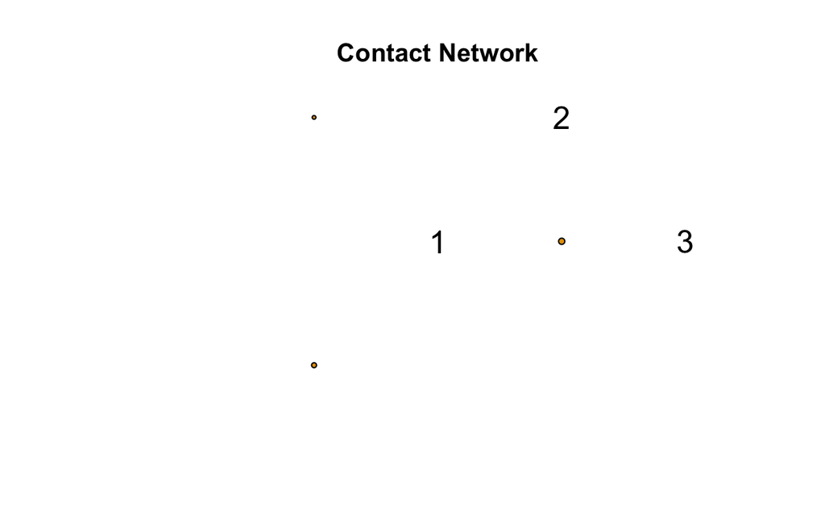

```r
# Load the igraph package
library(igraph)
# Define the particle positions and radii
x <- c(0, 1, 2)
y <- c(0, 1, 0)
r <- c(0.5, 0.3, 0.4)

# Create a graph object representing the particles
g <- graph.empty(n = length(x), directed = FALSE)

# Add the nodes to the graph
V(g)$x <- x
V(g)$y <- y
V(g)$r <- r

# Add the edges to the graph (i.e., the contacts between particles)
for (i in 1:(length(x)-1)) {
  for (j in (i+1):length(x)) {
    dist <- sqrt((x[i]-x[j])^2 + (y[i]-y[j])^2)
    if (dist < r[i] + r[j]) {
      g <- add_edges(g, c(i,j))
    }
  }
}

# Plot the contact network
plot(g, layout = layout.circle(g), vertex.size = V(g)$r*10, edge.arrow.mode = "last", edge.arrow.size = 0.5, edge.width = 2,
     vertex.label = NA, main = "Contact Network")

# Add arrows for the contacts
E(g)$arrow.mode <- 1

# Add labels for the particles
text(x, y, labels = 1:length(x), cex = 1.5)
```

Shah Nawaz: what is contact moment in discrete element modelling

Raycast AI: In discrete element modelling, contact moment refers to the moment or torque that is generated at the contact point between two particles due to the forces acting on them. It is calculated based on the relative positions, velocities, and orientations of the particles, as well as the material properties and contact parameters. Contact moments play a crucial role in determining the dynamics and behavior of granular materials, such as their flow, compaction, and deformation.

Shah Nawaz: what is its mathematical form

Raycast AI: The mathematical form of contact moment in discrete element modelling depends on the specific contact model being used. In general, it can be expressed as the vector cross product of the contact force and the vector connecting the contact point to the center of mass of one of the particles:

M = r x F

where M is the contact moment, r is the position vector from the center of mass of one particle to the contact point, and F is the contact force vector. The direction of the moment vector is determined by the right-hand rule, and its magnitude depends on the relative orientations of the particles and the material properties of the contact interface.

Shah Nawaz: what happens to contact force in this case

Raycast AI: In the context of discrete element modeling, the contact force between two particles depends on their relative positions, velocities, and material properties, as well as the contact parameters such as stiffness, damping, and friction. The contact force can change over time as the particles move and interact with each other.

The contact moment, on the other hand, is a measure of the torque or rotational force that is generated at the contact point due to the contact force. It describes the tendency of the particles to rotate around their center of mass.

In general, the contact force and contact moment are both important quantities in discrete element modeling, and they interact with each other to determine the overall behavior of the system.

Shah Nawaz: how contact torque is measured

Raycast AI: In discrete element modeling, contact torque is typically calculated rather than measured directly. It is calculated based on the positions, velocities, and orientations of the particles, as well as the material properties and contact parameters that are specified in the simulation.

To calculate the contact torque, the contact force vector and the position vector from the center of mass of one particle to the contact point are first determined. The torque vector is then obtained by taking the cross product of these two vectors, as follows:

M = r x F

where M is the contact torque, r is the position vector, and F is the contact force vector. The direction of the torque vector is determined by the right-hand rule, and its magnitude depends on the relative orientations of the particles and the material properties of the contact interface.

The contact torque, along with the contact force and other quantities such as particle velocities and accelerations, can be used to analyze the dynamics and behavior of granular materials in discrete element simulations.

Shah Nawaz: show equations of contact torque with more complex equations from reasearch papers

Raycast AI: The equation for contact torque in discrete element modeling can be more complex depending on the specific contact model and simulation parameters used. Here are a few examples of equations for contact torque from research papers:

1. In a study of the rolling resistance of granular materials, the contact torque was modeled using a Hertz-Mindlin contact model with Coulomb friction. The contact torque was given by:

M = r x F + (1 - alpha) * (r x F_t) * (r x n)

where M is the contact torque, r is the position vector from the center of mass of one particle to the contact point, F is the contact force vector, F_t is the tangential force vector, n is the normal vector, and alpha is a rolling resistance parameter. This equation includes an additional term that accounts for the rolling resistance of the particles.

2. In a study of the effect of particle shape on the flow behavior of granular materials, the contact torque was modeled using a soft-sphere contact model with tangential friction. The contact torque was given by:

M = r x F_t + (1 - beta) * (r x F_t) * (r x n) + gamma * (r x v_t)

where M is the contact torque, r is the position vector from the center of mass of one particle to the contact point, F_t is the tangential force vector, n is the normal vector, v_t is the tangential velocity vector, beta is a frictional parameter, and gamma is a rotational damping parameter. This equation includes additional terms that account for the effects of tangential friction and rotational damping on the contact torque.

These equations demonstrate that the contact torque in discrete element modeling can be influenced by a variety of factors, including particle shape, contact model, and simulation parameters.

Shah Nawaz: if the particle shape is spherical what will be the role of damping

Raycast AI: If the particle shape is spherical, the role of damping in the contact torque equation may be to account for the rotational energy dissipation that occurs during particle-particle collisions and interactions.

In a discrete element simulation of spherical particles, the contact torque between two particles can be modeled using a soft-sphere contact model with tangential friction. The contact torque equation in this case would be:

M = r x F_t + gamma * (r x v_t)

where M is the contact torque, r is the position vector from the center of mass of one particle to the contact point, F_t is the tangential force vector, v_t is the tangential velocity vector, and gamma is a rotational damping coefficient.

The term gamma * (r x v_t) represents the damping torque, which is proportional to the relative tangential velocity between the particles and the rotational damping coefficient. This term accounts for the energy dissipation that occurs due to the rotational motion of the particles during contact.

In general, the role of damping in the contact torque equation depends on the specific contact model and simulation parameters used, as well as the physical properties of the particles being simulated.

Shah Nawaz: how rotational and rolling motion takes place in dem

Raycast AI: In discrete element modeling (DEM), rotational and rolling motion of particles are typically modeled using contact models that include rotational degrees of freedom. In these models, particles are treated as rigid bodies that can rotate and translate in response to the forces and torques that act on them.

Rotational motion occurs when a particle experiences a torque or moment at its contact points with other particles or boundaries. The torque causes the particle to rotate around its center of mass, changing its orientation and angular velocity. The rotational motion of a particle can be described using the equations of rotational motion, which relate the torque, angular acceleration, and angular velocity of the particle.

Rolling motion occurs when a particle experiences a net force and torque at its contact points that result in a combination of rotational and translational motion. Rolling motion is important in DEM simulations of granular materials, as it can affect the overall behavior and properties of the material, such as its packing density, flow rate, and shear strength.

To model rolling motion in DEM, contact models that include rolling resistance and frictional forces are used. These models take into account the shape, size, and material properties of the particles, as well as the contact parameters such as stiffness, damping, and friction. The rolling motion of a particle can be described using the equations of motion, which relate the net force, torque, linear acceleration, and angular acceleration of the particle.